# Setting Up - Install Packages in the Workspace

Before you move on to the project instruction, follow the cells below to ensure you have the necessary packages installed. The cells below will also educate you on installing newer pinned packages, should you need them in the future.

```python
# Step 1. Update the PATH env var.
import os
os.environ['PATH'] = f"{os.environ['PATH']}:/home/student/.local/bin"
os.environ['PATH'] = f"{os.environ['PATH']}:/opt/conda/lib/python3.10/site-packages"
os.environ['PROTOCOL_BUFFERS_PYTHON_IMPLEMENTATION'] = 'python'
```

```python
!pip install -r requirements.txt
```

```python
# Check the version of any specific package
!python -m pip freeze | grep numpy
```

```
numpy @ file:///work/mkl/numpy_and_numpy_base_1682953417311/work
```

```python
import matplotlib.pyplot as plt
%matplotlib inline
```

# Navigation

You are welcome to use this coding environment to train your agent for the project. Follow the instructions below to get started!

### 1. Start the Environment

Run the next code cell to install a few packages. This line will take a few minutes to run!

```python
!pip -q install .
```

The environment is already saved in the Workspace and can be accessed at the file path provided below. Please run the next code cell without making any changes.

```python
# Restart the Kernel.
# If you skip this step, your notebook may not be able to import the packages well.
```

```python
from unityagents import UnityEnvironment
import numpy as np

# please do not modify the line below
env = UnityEnvironment(file_name="/data/Banana_Linux_NoVis/Banana.x86_64")
```

```
Found path: /data/Banana_Linux_NoVis/Banana.x86_64
Mono path[0] = '/data/Banana_Linux_NoVis/Banana_Data/Managed'
Mono config path = '/data/Banana_Linux_NoVis/Banana_Data/MonoBleedingEdge/etc'
Preloaded 'libgrpc_csharp_ext.x64.so'
Unable to preload the following plugins:
	libgrpc_csharp_ext.x86.so
Logging to /home/student/.config/unity3d/Unity Technologies/Unity Environment/Player.log
```

```
INFO:unityagents:
'Academy' started successfully!
Unity Academy name: Academy
        Number of Brains: 1
        Number of External Brains : 1
        Lesson number : 0
        Reset Parameters :

Unity brain name: BananaBrain
        Number of Visual Observations (per agent): 0
        Vector Observation space type: continuous
        Vector Observation space size (per agent): 37
        Number of stacked Vector Observation: 1
        Vector Action space type: discrete
        Vector Action space size (per agent): 4
        Vector Action descriptions: , , ,
```

Environments contain *brains* which are responsible for deciding the actions of their associated agents. Here we check for the first brain available, and set it as the default brain we will be controlling from Python.

```python
# get the default brain
brain_name = env.brain_names[0]
brain = env.brains[brain_name]
```

### 2. Examine the State and Action Spaces

Run the code cell below to print some information about the environment.

```python
# reset the environment
env_info = env.reset(train_mode=True)[brain_name]

# number of agents in the environment
print('Number of agents:', len(env_info.agents))

# number of actions
action_size = brain.vector_action_space_size
print('Number of actions:', action_size)

# examine the state space
state = env_info.vector_observations[0]
print('States look like:', state)
state_size = len(state)
print('States have length:', state_size)
```

```
Number of agents: 1
Number of actions: 4
States look like: [1.         0.         0.         0.         0.84408134 0.
 0.         1.         0.         0.0748472  0.         1.
 0.         0.         0.25755    1.         0.         0.
 0.         0.74177343 0.         1.         0.         0.
 0.25854847 0.         0.         1.         0.         0.09355672
 0.         1.         0.         0.         0.31969345 0.
 0.        ]
States have length: 37
```

### 3. Take Random Actions in the Environment

In the next code cell, you will learn how to use the Python API to control the agent and receive feedback from the environment.

Note that **in this coding environment, you will not be able to watch the agent while it is training**, and you should set `train_mode=True` to restart the environment.

```python
env_info = env.reset(train_mode=True)[brain_name] # reset the environment
state = env_info.vector_observations[0]            # get the current state
score = 0                                          # initialize the score
while True:
    action = np.random.randint(action_size)        # select an action
    env_info = env.step(action)[brain_name]        # send the action to the environment
    next_state = env_info.vector_observations[0]   # get the next state
    reward = env_info.rewards[0]                   # get the reward
    done = env_info.local_done[0]                  # see if episode has finished
    score += reward                                # update the score
    state = next_state                             # roll over the state to next time step
    if done:                                       # exit loop if episode finished
        break

print("Score: {}".format(score))
```

```
Score: 0.0
```

When finished, you can close the environment.

```python
env.close()
```

### 4. It's Your Turn!

Now it's your turn to train your own agent to solve the environment! A few **important notes**:

- When training the environment, set `train_mode=True`, so that the line for resetting the environment looks like the following:

```
env_info = env.reset(train_mode=True)[brain_name]
```

- To structure your work, you're welcome to work directly in this Jupyter notebook, or you might like to start over with a new file! You can see the list of files in the workspace by clicking on *Jupyter* in the top left corner of the notebook.
- In this coding environment, you will not be able to watch the agent while it is training. However, *after training the agent*, you can download the saved model weights to watch the agent on your own machine!

# Deep Q-Network Architecture

This implementation includes a neural network model for approximating Q-values in Deep Q-Learning. The architecture consists of:

1. **Input Layer**: Takes state observations as input
2. **Hidden Layers**: Configurable fully connected layers with ReLU activation
3. **Output Layer**: Produces Q-values for each possible action

## Key Features:

- Dynamic hidden layer configuration
- Automatic network construction using OrderedDict
- ReLU activation between layers (except final layer)
- Proper initialization with random seed
- Efficient forward pass implementation

The network is designed to be flexible and can be easily modified by adjusting the `hidden_layers` parameter. The default architecture uses two hidden layers of size 512, but this can be customized based on the complexity of the environment.

## Network Flow:

```
Input → [Linear → ReLU] × n → Linear → Output
```

```python
import torch
import torch.nn as nn
import torch.nn.functional as F
from collections import OrderedDict

class QNetwork(nn.Module):
    """Neural network for approximating Q-values"""

    def __init__(self, state_size, action_size, seed, hidden_layers=[512, 512]):
        """
        Initialize Q-Network

        Args:
            state_size: Input dimension (state space)
            action_size: Output dimension (action space)
            seed: Random seed for reproducibility
            hidden_layers: List of hidden layer sizes (default: [512, 512])
        """
        super().__init__()
        torch.manual_seed(seed)

        sizes = [state_size] + hidden_layers + [action_size]
        network_layers = OrderedDict(
            (k, v) for i in range(len(sizes)-1)
            for k, v in (
                lambda i: {
                    f'linear_{i}': nn.Linear(sizes[i], sizes[i+1]),
                    f'relu_{i}': nn.ReLU()
                } if i < len(sizes)-2 else {
                    f'linear_{i}': nn.Linear(sizes[i], sizes[i+1])
                }
            )(i).items()
        )

        self.network = nn.Sequential(network_layers)

    def forward(self, state):
        """
        Forward pass through network

        Args:
            state: Input state tensor

        Returns:
            Q-values for each action
        """
        return self.network(state)
```

# Dueling Deep Q-Network Architecture

This implementation features a dueling architecture for Deep Q-Learning, which separates the estimation of state values and action advantages. The network consists of:

1. **Feature Layer**: Common initial layer for extracting state features
2. **Value Stream**: Estimates the value function V(s) for each state
3. **Advantage Stream**: Estimates the advantage function A(s,a) for each action

## Key Features:

- Separate value and advantage streams
- Dynamic hidden layer configuration for both streams
- ReLU activation functions throughout
- Proper initialization with random seed
- Efficient stream combination using advantage mean normalization

## Network Flow:

```
                    /-> [Value Stream] -> V(s)
Input -> Features -
                    \-> [Advantage Stream] -> A(s,a)

Q(s,a) = V(s) + (A(s,a) - mean(A(s,a)))
```

The dueling architecture helps the network learn which states are valuable without having to learn the effect of each action at each state, leading to better policy evaluation.

```python
import torch
import torch.nn as nn
import torch.nn.functional as F
from collections import OrderedDict

class DuelingQNetwork(nn.Module):
    """Neural network for dueling DQN architecture"""

    def __init__(self, state_size, action_size, seed, hidden_layers, hidden_state_value):
        """
        Initialize Dueling Q-Network

        Args:
            state_size: Dimension of state space
            action_size: Dimension of action space
            seed: Random seed for reproducibility
            hidden_layers: List of hidden layer sizes for advantage stream
            hidden_state_value: List of hidden layer sizes for state value stream
        """
        super().__init__()
        torch.manual_seed(seed)

        # Feature layer
        self.feature = nn.Linear(state_size, hidden_layers[0])

        # Advantage stream
        self.advantage_hidden = nn.ModuleList()
        prev_layer_size = hidden_layers[0]
        for layer_size in hidden_layers[1:]:
            self.advantage_hidden.append(nn.Linear(prev_layer_size, layer_size))
            prev_layer_size = layer_size
        self.advantage_output = nn.Linear(prev_layer_size, action_size)

        # State value stream
        self.value_hidden = nn.ModuleList()
        prev_layer_size = hidden_layers[0]  # Start from feature layer size
        for layer_size in hidden_state_value:
            self.value_hidden.append(nn.Linear(prev_layer_size, layer_size))
            prev_layer_size = layer_size
        self.value_output = nn.Linear(prev_layer_size, 1)

    def forward(self, state):
        """Forward pass through network"""
        # Common feature layer
        x = F.relu(self.feature(state))

        # Advantage stream
        advantage = x
        for layer in self.advantage_hidden:
            advantage = F.relu(layer(advantage))
        advantage = self.advantage_output(advantage)

        # State value stream
        value = x
        for layer in self.value_hidden:
            value = F.relu(layer(value))
        value = self.value_output(value)

        # Combine streams
        return value + (advantage - advantage.mean(dim=1, keepdim=True))
```

# Experience Replay Buffer

This implementation features a replay buffer for storing and sampling experience tuples in Deep Q-Learning. The buffer helps break the correlation between consecutive samples and enables mini-batch learning.

## Key Components:

1. **Memory Storage**: Fixed-size deque for storing experiences
2. **Experience Tuple**: Named tuple containing (state, action, reward, next_state, done)
3. **Batch Sampling**: Random sampling of experiences for training
4. **Tensor Conversion**: Efficient conversion of experiences to PyTorch tensors

## Features:

- Configurable buffer size and batch size
- Automatic handling of device placement (CPU/GPU)
- Efficient memory management using deque
- Random seed for reproducibility
- Automatic tensor type conversion

## Memory Flow:

```
Add: Experience -> Deque Buffer
Sample: Buffer -> Random Batch -> Torch Tensors
```

The replay buffer is essential for stable learning in DQN by enabling random sampling of past experiences, which helps reduce the correlation between consecutive training samples.

```python
import numpy as np
import torch
import random
from collections import namedtuple, deque

class ReplayBuffer:
    """Memory buffer for storing and sampling experience tuples"""

    def __init__(self, action_size, buffer_size, batch_size, seed, device):
        """
        Initialize Replay Buffer

        Args:
            action_size: Dimension of each action
            buffer_size: Maximum size of buffer
            batch_size: Size of each training batch
            seed: Random seed for reproducibility
            device: Device to store tensors on (cuda/cpu)
        """
        self.action_size = action_size
        self.memory = deque(maxlen=buffer_size)
        self.batch_size = batch_size
        self.device = device

        # Create named tuple for experiences
        self.Experience = namedtuple("Experience",
            field_names=["state", "action", "reward", "next_state", "done"])
        random.seed(seed)

    def add(self, state, action, reward, next_state, done):
        """
        Add experience to memory

        Args:
            state: Current state
            action: Action taken
            reward: Reward received
            next_state: Next state
            done: Episode termination flag
        """
        experience = self.Experience(state, action, reward, next_state, done)
        self.memory.append(experience)

    def sample(self):
        """
        Sample random batch of experiences

        Returns:
            Tuple of (states, actions, rewards, next_states, dones, None)
            All items are torch tensors except the last None
        """
        experiences = random.sample(self.memory, k=self.batch_size)

        # Convert to torch tensors using list comprehension
        to_tensor = lambda x, dtype: torch.from_numpy(
            np.vstack([getattr(e, x) for e in experiences if e is not None])
        ).to(self.device, dtype=dtype)

        states = to_tensor('state', torch.float32)
        actions = to_tensor('action', torch.int64)
        rewards = to_tensor('reward', torch.float32)
        next_states = to_tensor('next_state', torch.float32)
        dones = to_tensor('done', torch.float32).view(-1, 1)

        return states, actions, rewards, next_states, dones, None

    def __len__(self):
        """Current size of internal memory"""
        return len(self.memory)
```

# Prioritized Experience Replay Buffer

This implementation enhances the standard replay buffer with prioritized sampling, which helps focus learning on the most important experiences. The buffer uses TD-errors to determine the importance of each experience.

## Key Components:

1. **Prioritized Storage**: Structured numpy array for experiences and their priorities
2. **Priority-based Sampling**: Weighted sampling based on TD-errors
3. **Importance Sampling**: Correction for the bias introduced by non-uniform sampling
4. **Priority Updates**: Dynamic updating of experience priorities based on learning

## Advanced Features:

- Configurable prioritization (α) and importance sampling (β) parameters
- Automatic beta scheduling for annealing importance sampling
- Efficient numpy-based priority management
- Memory-efficient pre-allocated arrays
- Automatic handling of priority updates

## Priority Mechanism:

```
Experience Priority = |TD-Error|^α
Sampling Probability ∝ Priority
Importance Weight = (1/N * 1/P(i))^β
```

The prioritized replay helps the agent learn more effectively by focusing on experiences with higher TD-errors, while importance sampling ensures unbiased updates.

```python
import numpy as np
import torch

class PrioritizedReplayBuffer:
    """Memory buffer with prioritized sampling for experience replay"""

    def __init__(self, action_size, buffer_size, batch_size, seed, device,
                 alpha=0., beta=1., beta_scheduler=1.):
        """
        Initialize Prioritized Replay Buffer

        Args:
            action_size: Dimension of each action
            buffer_size: Maximum size of buffer
            batch_size: Size of each training batch
            seed: Random seed for reproducibility
            device: Device to store tensors on (cuda/cpu)
            alpha: Prioritization exponent (0 = uniform sampling)
            beta: Importance sampling correction exponent
            beta_scheduler: Beta increase rate (>= 1.0)
        """
        self.action_size = action_size
        self.buffer_size = buffer_size
        self.batch_size = batch_size
        self.device = device
        self.alpha = alpha
        self.beta = beta
        self.beta_scheduler = beta_scheduler
        np.random.seed(seed)

        # Initialize memory structures
        self.memory = np.empty(buffer_size, dtype=[
            ("state", np.ndarray),
            ("action", np.int),
            ("reward", np.float),
            ("next_state", np.ndarray),
            ("done", np.bool),
            ('prob', np.double)
        ])

        # Memory control variables
        self.memory_idx = 0
        self.sample_indices = np.empty(batch_size)
        self.samples = np.empty(batch_size, dtype=type(self.memory))

        # Priority parameters
        self.max_prob = 1e-4
        self.min_prob = 1e-5

        # Pre-allocate arrays for efficiency
        self.probabilities = np.empty(buffer_size, dtype=np.double)
        self.weights = np.empty(buffer_size, dtype=np.double)

    def add(self, state, action, reward, next_state, done):
        """
        Add experience to memory

        Args:
            state: Current state
            action: Action taken
            reward: Reward received
            next_state: Next state
            done: Episode termination flag
        """
        self.memory[self.memory_idx] = (state, action, reward, next_state, done, self.max_prob)
        self.memory_idx = (self.memory_idx + 1) % self.buffer_size

    def sample(self):
        """
        Sample batch of experiences using priorities

        Returns:
            Tuple of (states, actions, rewards, next_states, dones, weights)
            All items are torch tensors
        """
        # Compute sampling probabilities
        np.divide(self.memory['prob'], self.memory['prob'].sum(), out=self.probabilities)

        # Sample experiences
        self.sample_indices = np.random.choice(
            self.buffer_size, self.batch_size, replace=False, p=self.probabilities)
        self.samples = self.memory[self.sample_indices]

        # Compute importance sampling weights
        np.multiply(self.memory['prob'], self.buffer_size, out=self.weights)
        np.power(self.weights, -self.beta, out=self.weights, where=self.weights!=0)
        np.divide(self.weights, self.weights.max(), out=self.weights)

        # Update beta
        self.beta = min(1, self.beta * self.beta_scheduler)

        # Convert to torch tensors
        to_tensor = lambda x, dtype: torch.from_numpy(
            np.vstack(self.samples[x])).to(self.device, dtype=dtype)

        states = to_tensor('state', torch.float32)
        actions = to_tensor('action', torch.int64)
        rewards = to_tensor('reward', torch.float32)
        next_states = to_tensor('next_state', torch.float32)
        dones = to_tensor('done', torch.float32)
        weights = torch.from_numpy(self.weights[self.sample_indices]).float().to(self.device)

        return states, actions, rewards, next_states, dones, weights

    def update_priorities(self, td_error):
        """
        Update priorities for sampled experiences

        Args:
            td_error: TD-error for sampled experiences
        """
        td_error.pow_(self.alpha)
        td_error.add_(self.min_prob)

        self.samples['prob'] = td_error
        self.memory[self.sample_indices] = self.samples
        self.max_prob = self.memory['prob'].max()

    def __len__(self):
        """Current size of internal memory"""
        return self.buffer_size if self.memory_idx // self.buffer_size > 0 else self.memory_idx
```

# DQN Agent Implementation

This implementation combines several advanced Deep Q-Learning techniques into a single agent. The agent can utilize Double DQN, Dueling Networks, and Prioritized Experience Replay based on configuration.

## Core Components:

1. **Networks**:
   - Local network for action selection
   - Target network for stable learning
   - Optional Dueling architecture
2. **Memory**:
   - Standard or Prioritized Experience Replay
   - Configurable buffer size and batch size
3. **Learning**:
   - Double DQN for better action value estimation
   - Soft target network updates
   - Gradient clipping for stability
   - Learning rate decay

## Hyperparameters:

```
Buffer Size: 100,000
Batch Size: 64
Gamma: 0.99
TAU: 0.01
Learning Rate: 0.00048
Update Frequency: 4
```

## Advanced Features:

- Automatic device placement (CPU/GPU)
- Configurable network architectures
- Epsilon-greedy exploration
- TD-error based prioritization
- Importance sampling correction
- Gradient norm clipping

The agent combines these techniques to achieve stable and efficient learning in complex environments.

```python
import numpy as np
import random
import torch
import torch.nn.functional as F
import torch.optim as optim

# Configuration constants
BUFFER_SIZE = int(1e5)
BATCH_SIZE = 64
GAMMA = 0.99
TAU = 1e-2
LR = 4.8e-4
UPDATE_EVERY = 4

# Global settings
device = torch.device("cuda:0" if torch.cuda.is_available() else "cpu")
USE_DOUBLE_DQN = True
USE_PRIORITIZED_REPLAY = False
USE_DUELING_NETWORK = True

class Agent:
    """Agent that interacts with and learns from the environment"""

    def __init__(self, state_size, action_size, seed, lr_decay=0.9999):
        """Initialize an Agent object.

        Params
        ======
            state_size (int): dimension of each state
            action_size (int): dimension of each action
            seed (int): random seed
            lr_decay (float): multiplicative factor of learning rate decay
        """
        self.state_size = state_size
        self.action_size = action_size
        self.seed = random.seed(seed)

        print("Running on: "+str(device))

        # Q-Network
        hidden_layers = [128, 64]  # Advantage stream hidden layers
        hidden_state_value = [64, 32]  # State value stream hidden layers

        if USE_DUELING_NETWORK:
            self.qnetwork_local = DuelingQNetwork(
                state_size,
                action_size,
                seed,
                hidden_layers=hidden_layers,
                hidden_state_value=hidden_state_value
            ).to(device)

            self.qnetwork_target = DuelingQNetwork(
                state_size,
                action_size,
                seed,
                hidden_layers=hidden_layers,
                hidden_state_value=hidden_state_value
            ).to(device)
        else:
            self.qnetwork_local = QNetwork(state_size, action_size, seed, hidden_layers).to(device)
            self.qnetwork_target = QNetwork(state_size, action_size, seed, hidden_layers).to(device)

        self.optimizer = optim.Adam(self.qnetwork_local.parameters(), lr=LR)
        self.lr_scheduler = optim.lr_scheduler.ExponentialLR(self.optimizer, lr_decay)

        # Initialize replay memory
        if USE_PRIORITIZED_REPLAY:
            self.memory = PrioritizedReplayBuffer(
                action_size=action_size,
                buffer_size=BUFFER_SIZE,
                batch_size=BATCH_SIZE,
                seed=seed,
                device=device,
                alpha=0.6,
                beta=0.4,
                beta_scheduler=1.0
            )
        else:
            self.memory = ReplayBuffer(
                action_size=action_size,
                buffer_size=BUFFER_SIZE,
                batch_size=BATCH_SIZE,
                seed=seed,
                device=device
            )

        # Initialize time step (for updating every UPDATE_EVERY steps)
        self.t_step = 0

    def step(self, state, action, reward, next_state, done):
        """Store experience and learn if it's time"""
        self.memory.add(state, action, reward, next_state, done)

        self.t_step = (self.t_step + 1) % UPDATE_EVERY
        if self.t_step == 0 and len(self.memory) > BATCH_SIZE:
            experiences = self.memory.sample()
            self.learn(experiences, GAMMA)

    def act(self, state, eps=0.):
        """Select action using epsilon-greedy policy"""
        state = torch.from_numpy(state).float().unsqueeze(0).to(device)

        self.qnetwork_local.eval()
        with torch.no_grad():
            action_values = self.qnetwork_local(state)
        self.qnetwork_local.train()

        return np.argmax(action_values.cpu().data.numpy()) if random.random() > eps else \
               random.choice(np.arange(self.action_size))

    def learn(self, experiences, gamma):
        """Update value parameters using batch of experience tuples"""
        states, actions, rewards, next_states, dones, weights = experiences
        if not USE_PRIORITIZED_REPLAY:
            weights = torch.ones_like(rewards).to(device)

        with torch.no_grad():
            if USE_DOUBLE_DQN:
                next_actions = self.qnetwork_local(next_states).max(1)[1].unsqueeze(1)
                next_q_targets = self.qnetwork_target(next_states).gather(1, next_actions)
            else:
                next_q_targets = self.qnetwork_target(next_states).max(1)[0].unsqueeze(1)

            target_q_values = rewards + (gamma * next_q_targets * (1 - dones))

        current_q_values = self.qnetwork_local(states).gather(1, actions)

        if USE_PRIORITIZED_REPLAY:
            td_errors = target_q_values - current_q_values
            loss = (weights * td_errors.pow(2)).mean()

            with torch.no_grad():
                self.memory.update_priorities(td_errors.abs())
        else:
            loss = F.mse_loss(current_q_values, target_q_values)

        self.optimizer.zero_grad()
        loss.backward()
        torch.nn.utils.clip_grad_norm_(self.qnetwork_local.parameters(), 1.0)
        self.optimizer.step()
        self.lr_scheduler.step()

        self.soft_update(self.qnetwork_local, self.qnetwork_target, TAU)

    def soft_update(self, local_model, target_model, tau):
        """Soft update target model parameters"""
        for target_param, local_param in zip(target_model.parameters(), local_model.parameters()):
            target_param.data.copy_(tau * local_param.data + (1.0 - tau) * target_param.data)
```

# Training Loop Implementation

This section implements the main training loop for the Deep Q-Learning agent. The training process includes:

## Process Flow:

1. **Episode Initialization**:
   - Reset environment
   - Initialize episode score
2. **Step Loop**:
   - Select actions using epsilon-greedy policy
   - Execute actions in environment
   - Store experiences in replay buffer
   - Perform learning updates
3. **Progress Tracking**:
   - Monitor running average score
   - Track epsilon decay
   - Display training statistics

## Performance Monitoring:

```
Per Episode: Current score, Average score, Epsilon value, Learning rate
Per 100 Episodes: Detailed statistics
On Solving: Save network weights to checkpoint
```

The training loop provides comprehensive monitoring while maintaining efficient execution through vectorized operations and proper device management.

```python
from collections import deque

def dqn(n_episodes=2000, max_t=1000, eps_start=1.0, eps_end=0.01, eps_decay=0.995):
    """
    Deep Q-Learning training loop

    Args:
        n_episodes: Maximum number of training episodes
        max_t: Maximum timesteps per episode
        eps_start: Initial epsilon value for exploration
        eps_end: Minimum epsilon value
        eps_decay: Epsilon decay rate per episode

    Returns:
        scores: List of scores from each episode
        scores_mean: List of running mean scores
    """
    scores = []
    scores_mean = []
    scores_window = deque(maxlen=100)
    eps = eps_start

    for i_episode in range(1, n_episodes+1):
        # Initialize episode
        state = env.reset(train_mode=True)[brain_name].vector_observations[0]
        score = 0

        # Episode loop
        for t in range(max_t):
            # Select and perform action
            action = agent.act(state, eps)
            env_info = env.step(action)[brain_name]

            # Observe new state and reward
            next_state = env_info.vector_observations[0]
            reward = env_info.rewards[0]
            done = env_info.local_done[0]

            # Store transition and perform optimization
            agent.step(state, action, reward, next_state, done)

            # Update state and score
            state = next_state
            score += reward

            if done:
                break

        # Store scores and update statistics
        scores.append(score)
        scores_window.append(score)
        scores_mean.append(np.mean(scores_window))

        # Print progress
        print(f'\rEpisode {i_episode}\tAverage Score: {scores_mean[-1]:.2f}\t'
              f'eps: {eps:.4f}\tLR: {agent.lr_scheduler.get_lr()}', end="")

        # Update epsilon
        eps = max(eps_end, eps_decay * eps)

        # Print detailed progress every 100 episodes
        if i_episode % 100 == 0:
            print(f'\rEpisode {i_episode}\tAverage Score: {scores_mean[-1]:.2f}\t'
                  f'eps: {eps:.4f}\tLR: {agent.lr_scheduler.get_lr()}')

        # Check if environment is solved
        if np.mean(scores_window) >= 13.0:
            print(f'\nEnvironment solved in {i_episode-100:d} episodes!\t'
                  f'Average Score: {np.mean(scores_window):.2f}')
            torch.save(agent.qnetwork_local.state_dict(), 'checkpoint.pth')
            break

    return scores, scores_mean
```

# Environment and Agent Initialization

In this section, we set up the environment and initialize the agent for training. This involves:

## Key Steps:

1. **Environment Setup**:
   - Retrieve the brain name and brain object from the environment
   - Reset the environment to obtain initial state information
2. **Determine Action and State Sizes**:
   - Extract the action size from the brain's action space
   - Determine the state size from the initial state observation
3. **Agent Initialization**:
   - Create an instance of the `Agent` class with the determined state and action sizes
   - Set a random seed for reproducibility
   - Configure learning rate decay for the optimizer
4. **Training Execution**:
   - Invoke the `dqn` function to start the training process
   - Monitor the training progress through scores and running averages

## Debugging:

- Enable anomaly detection in PyTorch to catch and diagnose potential issues during backpropagation

This setup ensures that the agent is properly configured to interact with the environment and learn effectively through the training loop.

```python
torch.autograd.set_detect_anomaly(True)


brain_name = env.brain_names[0]
brain = env.brains[brain_name]

env_info = env.reset(train_mode=True)[brain_name]
action_size = brain.vector_action_space_size
state = env_info.vector_observations[0]
state_size = len(state)

agent = Agent(state_size=state_size, action_size=action_size, seed=0, lr_decay=0.9999)

## Train the Agent
scores, mean = dqn(n_episodes=200, max_t=300, eps_start=0.10, eps_end=0.01, eps_decay=0.987)
```

```
Running on: cuda:0
```

```
Episode 100	Average Score: 7.34	eps: 0.0270	LR: [0.00022706780570095735]
Episode 200	Average Score: 10.10	eps: 0.0100	LR: [0.00010725521420332037]
```

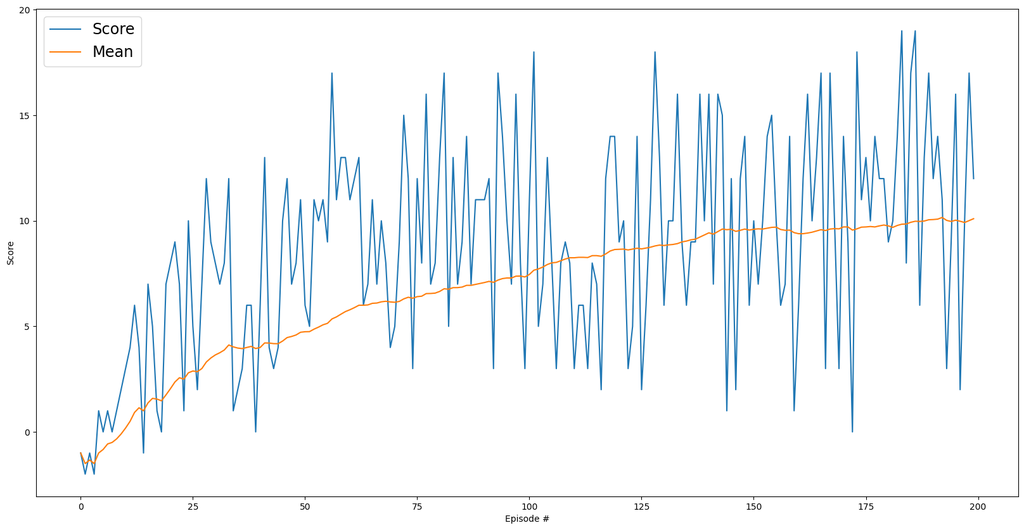

```python
## Plot the scores
fig = plt.figure(figsize=(20,10))

ax = fig.add_subplot(111)
plt.plot(np.arange(len(scores)), scores)
plt.plot(np.arange(len(mean)), mean)
plt.ylabel('Score')
plt.xlabel('Episode #')
plt.legend(('Score', 'Mean'), fontsize='xx-large')

plt.show()
```

The graph illustrates the performance of a value-based policy over a series of episodes during training. Here's an interpretation:

1. **Score (Blue Line)**:
   - Represents the score achieved in each episode.
   - Shows variability due to exploration and the stochastic nature of the environment.
   - Over time, the scores generally increase, indicating learning and improvement in policy performance.
2. **Mean (Orange Line)**:
   - Represents the running average of scores over a window of episodes (e.g., 100 episodes).
   - Provides a smoothed view of performance trends, reducing noise from individual episode fluctuations.
   - The upward trend in the mean line suggests that the agent is consistently improving its performance.
3. **Performance Trend**:
   - The increasing trend in both the score and mean lines indicates successful learning.
   - The agent is likely adapting its policy to maximize rewards effectively.
4. **Variability**:
   - The fluctuations in the score line highlight the exploration-exploitation trade-off.
   - Some episodes may have lower scores due to exploration, which is necessary for discovering optimal actions.

```python
## Create the environment
try:
    env
except:
    env = UnityEnvironment(environment_path)

    # Get the default brain
    brain_name = env.brain_names[0]
    brain = env.brains[brain_name]

    # Get the environment info
    env_info = env.reset(train_mode=False)[brain_name]
    action_size = brain.vector_action_space_size
    state = env_info.vector_observations[0]
    state_size = len(state)

    ## Create the DQN Agent
    agent = Agent(state_size=state_size, action_size=action_size, seed=0)

## Load the saved model
state_dict = torch.load('checkpoint.pth')
agent.qnetwork_local.load_state_dict(state_dict)
agent.qnetwork_local.eval()


n_episodes = 5
max_t = 300

## Train the Agent
scores = []       # list containing scores from each episode
scores_mean = []  # list the mean of the window scores
for i_episode in range(1, n_episodes+1):
    state = env.reset(train_mode=False)[brain_name].vector_observations[0]
    score = 0
    for t in range(max_t):
        action = agent.act(state)
        env_info = env.step(action)[brain_name]        # send the action to the environment
        next_state = env_info.vector_observations[0]   # get the next state
        reward = env_info.rewards[0]                   # get the reward
        done = env_info.local_done[0]                  # see if episode has finished
        state = next_state
        score += reward
        print('\rEpisode {}\Score: {:.2f}'.format(i_episode, score), end="")
        if done:
            break

    scores.append(score)              # save most recent score
    scores_mean.append(np.mean(scores))

    print('\rEpisode {}\Score: {:.2f}'.format(i_episode, scores[-1]))
```

[output not shown]

```python
## Create the environment
try:
    env
except:
    env = UnityEnvironment(environment_path)

    # Get the default brain
    brain_name = env.brain_names[0]
    brain = env.brains[brain_name]

    # Get the environment info
    env_info = env.reset(train_mode=False)[brain_name]
    action_size = brain.vector_action_space_size
    state = env_info.vector_observations[0]
    state_size = len(state)

    ## Create the DQN Agent
    agent = Agent(state_size=state_size, action_size=action_size, seed=0)

## Load the saved model
state_dict = torch.load('checkpoint.pth')
agent.qnetwork_local.load_state_dict(state_dict)
agent.qnetwork_local.eval()


n_episodes = 5
max_t = 300

## Train the Agent
scores = []       # list containing scores from each episode
scores_mean = []  # list the mean of the window scores
for i_episode in range(1, n_episodes+1):
    state = env.reset(train_mode=False)[brain_name].vector_observations[0]
    score = 0
    for t in range(max_t):
        action = agent.act(state)
        env_info = env.step(action)[brain_name]        # send the action to the environment
        next_state = env_info.vector_observations[0]   # get the next state
        reward = env_info.rewards[0]                   # get the reward
        done = env_info.local_done[0]                  # see if episode has finished
        state = next_state
        score += reward
        print('\rEpisode {}\Score: {:.2f}'.format(i_episode, score), end="")
        if done:
            break

    scores.append(score)              # save most recent score
    scores_mean.append(np.mean(scores))

    print('\rEpisode {}\Score: {:.2f}'.format(i_episode, scores[-1]))
```

[output not shown]

```python
## Close the environment
env.close()
```

```python
!jupyter nbconvert --to html Navigation.ipynb
```